# DistribucionesNotablesDiscretas

Guillem

8 April 2020

## Distribuciones Notables Discretas

### Distribución Binomial

Para una v.a X con distribución binomial $B(n = 10, p = 0.25)$

Si queremos calcular la función de distribución $F_X(0) = P(X\leq0)$

```r
pbinom(0, size = 10, prob = 0.25)
```

```
## [1] 0.05631351
```

y si queremos por ejemplo $F_X(4) = P(X\leq4)$

```r
pbinom(4, size = 10, prob = 0.25)
```

```
## [1] 0.9218731
```

No obstante, si queremos calcular la probabilidad por ejemplo $P(X = 0)$

```r
dbinom(0, size = 10, prob = 0.25)
```

```
## [1] 0.05631351
```

o por ejemplo para $P(X = 4)$

```r
dbinom(4, size = 10, prob = 0.25)
```

```
## [1] 0.145998
```

Generamos una muestra aleatoria de 100 valores de una población $B(20, 0.5)$

```r
rbinom(100, size = 20, prob = 0.5)
```

```
##   [1] 13  9 13  9 12  9 12 12 11 10 12 12 11 13  6  6 12  9  4 12 10 13  4 12 10
##  [26] 12 10 11  6  8 10 10  7  8  8  8 10 10  6  8 13  7  8 11 11 14 12  8 12 10
##  [51] 10 12  8  7 11 12  6  7  7 12  5 11  8 10  9 12 14  8  9 14  6 11  5 10 14
##  [76]  9  8  8 10 11  9 10 10 11  8  4  7  6  9 10 10 10 10 11 10 12 13  9  9 10
```

Vamos a dibujar la función de probabilidad y de distribución de una binomial

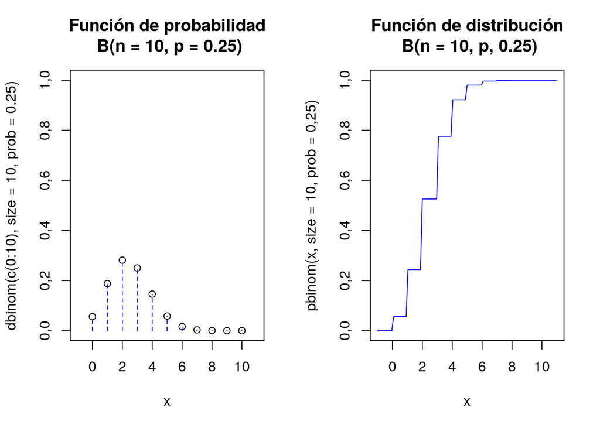

```r
par(mfrow = c(1,2))
aux <- rep(0,22)
aux[seq(2, 22, 2)] = dbinom(c(0:10), size = 10, prob = 0.25)
plot(x = c(0:10), y = dbinom(c(0:10), size = 10, prob = 0.25),
ylim = c(0, 1), xlim = c(-1, 11), xlab = "x",
main = "Función de probabilidad\n B(n = 10, p = 0.25)")
lines(x = rep(0:10, each = 2), y = aux, type = "h", lty = 2, col = "blue")
curve(pbinom(x, size = 10, prob = 0.25),
xlim = c(-1, 11), col = "blue", main = "Función de distribución\n B(n = 10, p, 0.25)")
```

```r
par(mfrow = c(1,1))
```

### Distribución Geométrica

Cuando $X ~ Ge(p = 0.25)$

$P(X = 0) = (1-0.25)^0 * 0.25^1 = 0.25$

```r
dgeom(0, prob = 0.25)
```

```
## [1] 0,25
```

$P(X \leq 0) = 1 - (1- 0.25)^{0+1} = 1 - 0.75 = 0.25$

```r
pgeom(0, prob = 0.25)
```

```
## [1] 0,25
```

$P(X \leq 4) = 1 - (1-0.25)^{4+1} = 1-0.75 = 1 - 0.75^5 = 0.7626953$

```r
pgeom(4, prob = 0.25)
```

```
## [1] 0,7626953
```

Si queremos sacar una muestra de tamaño 25 de una $Ge(0.25)$

```r
rgeom(n = 25, prob = 0.25)
```

```
##  [1] 3 0 1 0 6 0 2 4 8 2 3 5 0 6 1 2 1 0 5 0 1 2 0 3 1
```

Vamos a dibujar la función de probabilidad y de distribución de una geometrica

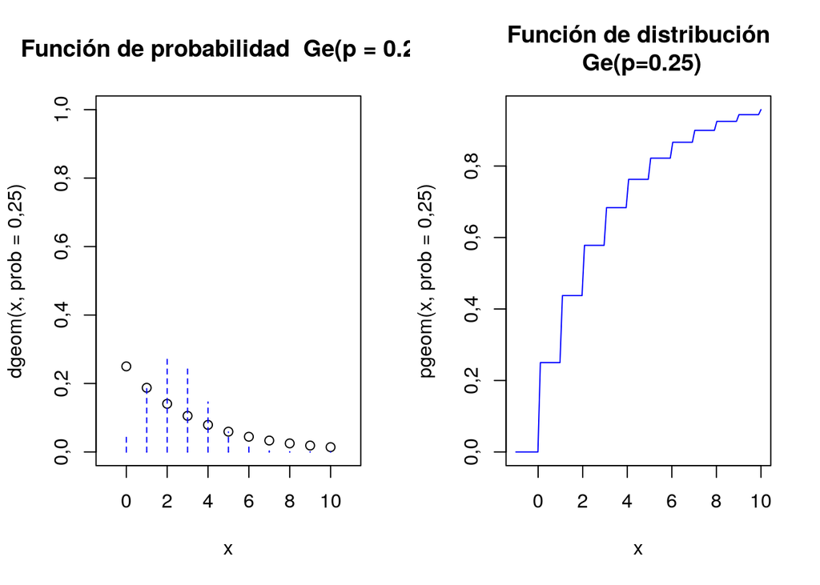

```r
par(mfrow = c(1, 2))
x <- c(0:10)
plot(x=x, y = dgeom(x, prob=0.25),
      ylim = c(0, 1), xlim = c(-1, 11), xlab = "x",
      main = "Función de probabilidad \ Ge(p = 0.25)")
lines(x = rep(0:10, each = 2), y = aux, type = "h", lty = 2, col = "blue")
aux0 <- dgeom(c(0:10), prob = 0.25)
ceros <- rep(0,21)
aux = ceros
aux[2*(c(1:11))] <- aux0
curve(pgeom(x, prob = 0.25),
      xlim = c(-1, 10), col = "blue",
      main = "Función de distribución\n Ge(p=0.25)")
```

```r
par(mfrow = c(1, 1))
```

### Binomial Negativa

Considerando que X ~ $BN(2, 0.1)$ y queremos calcular P(X = 5)

$P(X = 5) = {5+2-1\choose1} \cdot (1-0.1)^5 \cdot 0.1^2$

```r
dnbinom(5, size = 2, p = 0.1)
```

```
## [1] 0,0354294
```

```r
pnbinom(4, size = 2, p = 0.1, lower.tail = FALSE)
```

```
## [1] 0,885735
```

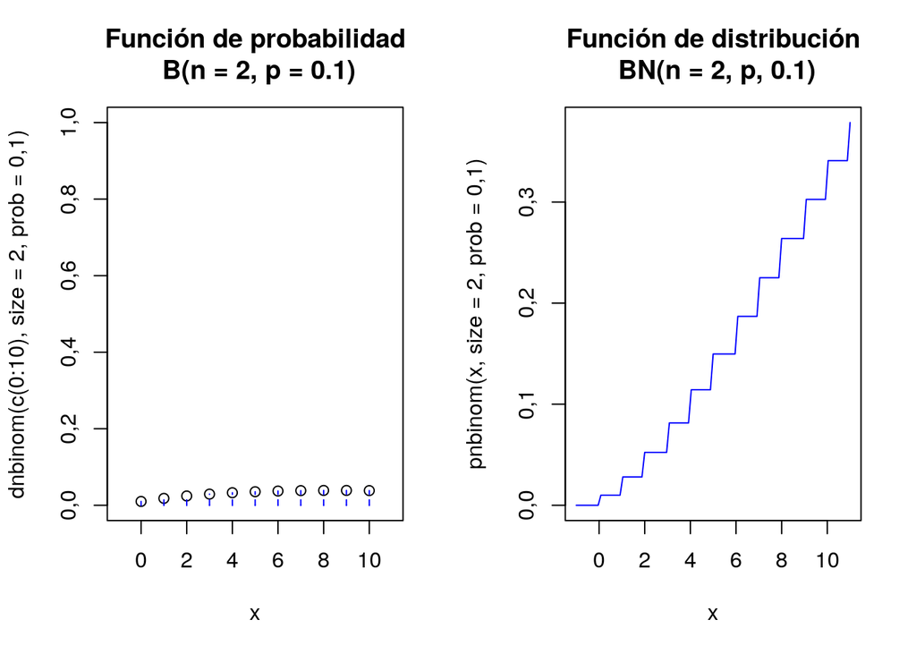

```r
par(mfrow = c(1,2))
aux <- rep(0,22)
aux[seq(2, 22, 2)] <- dnbinom(c(0:10), size = 2, prob = 0.1)
plot(x = c(0:10), y = dnbinom(c(0:10), size = 2, prob = 0.1),
ylim = c(0, 1), xlim = c(-1, 11), xlab = "x",
main = "Función de probabilidad\n B(n = 2, p = 0.1)")
lines(x = rep(0:10, each = 2), y = aux, type = "h", lty = 2, col = "blue")
curve(pnbinom(x, size = 2, prob = 0.1),
xlim = c(-1, 11), col = "blue", main = "Función de distribución\n BN(n = 2, p, 0.1)")
```

```r
par(mfrow = c(1,1))
```

# Distribución Poisson

Sea X una v.a. $Po(\lambda = 3)$

$$P(X = x) = \frac{\lambda^x}{x!} \cdot e^{-\lambda}$$

```r
dpois(0, lambda = 3)
```

```
## [1] 0,04978707
```

```r
dpois(1, lambda = 3)
```

```
## [1] 0,1493612
```

```r
ppois(0, lambda = 3)
```

```
## [1] 0,04978707
```

```r
ppois(1, lambda = 3)
```

```
## [1] 0,1991483
```

```r
dpois(0, lambda = 3) + dpois(1, lambda = 3)
```

```
## [1] 0,1991483
```

```r
rpois(n = 100, lambda = 3)
```

```
##   [1] 7 3 1 2 5 7 2 2 2 2 4 2 4 3 9 2 3 2 3 2 2 6 4 6 5 1 5 6 1 1 2 0 3 0 1 4 3
##  [38] 3 2 5 3 2 4 1 3 6 4 2 4 6 7 3 3 1 3 2 1 5 3 2 2 2 4 2 1 1 4 5 6 6 4 0 3 2
##  [75] 1 0 2 4 2 3 3 3 0 3 2 9 4 2 5 1 1 5 2 3 2 5 4 5 4 2
```

```r
lambda=20
par(mfrow=c(1,2))
n=qpois(0.99,lambda=lambda)
aux=rep(0,(n+1)*2)
aux[seq(2,(n+1)*2,2)]=dpois(c(0:n),lambda=lambda)
ymax=max(ppois(0:n,lambda=lambda))
plot(x=c(0:n),y=dpois(c(0:n),lambda=lambda),
     ylim=c(0,ymax),xlim=c(-1,n+1),xlab="x",ylab="Función de probabilidad",
     main=paste0(c("Función de probabilidad\n  Po(lambda=",lambda,")"),collapse = ""))
lines(x=rep(0:n,each=2),y=aux,pch=21, type = "h", lty = 2,col="blue")
curve(ppois(x,lambda=lambda),
      xlim=c(-1,n+1),col="blue",ylab="Función de Distribución",
      main=paste0(c("Función de distribución \n Po(lambda=",lambda,")"),collapse = ""))
par(mfrow=c(1,1))
```

[output not shown]

# Distribución Hipergeometrica

$P(X = 2) = \frac{{15}\choose{2}\cdot{10}\choose{1}}{{25}\choose{3}}$